# Classifying Human Activity from Wereable Accelerometer Data

mbandi

2026-03-22

## Overview

This is the project for the Practical Machine Learning curse at Cursera. The objective is to use a subset from the Weight Lifting Exercises Dataset from [Qualitative Activity Recognition of Weight Lifting Exercises](https://web.archive.org/web/20170519033209/http://groupware.les.inf.puc-rio.br/public/papers/2013.Velloso.QAR-WLE.pdf) to categorize readings from different wearable sensors. Four sensors were used, at the users’ globe, armband, lumbar belt and dumbell. Each participant was asked to repeat a movement in 5 different ways, one correct and 4 corresponding to common mistakes, resulting in the “classe” variable. Four models (decision tree, gradient boosting, support vector machine and random fores) will be trained and validated to find the most accurate in order to predict the test dataset. A recursive feature elimination will be used to find the most relevant variables to train the models.

The original study aimed to distinguish when an activity was realized correctly and when errors in the movement where made (hip position, limb movement, etc.). Usually, the human activity recognition studies with wearable sensors are focused in distinguishing between different types of activities (walking, running, sit ups, etc), and only a few try to detect variations in the same movement type to assert that the activity is being done properly. This could be particularly useful to remotely monitor elderly people or rehabilitation patients.

The original source for the dataset and the related studies can be found in [Human Activity Recognition](https://web.archive.org/web/20161224072740/http:/groupware.les.inf.puc-rio.br/har)

Links to the data used for this project can be found in:

Training set: https://d396qusza40orc.cloudfront.net/predmachlearn/pml-training.csv

Testing set: https://d396qusza40orc.cloudfront.net/predmachlearn/pml-testing.csv

### Loading the data

```r
library(dplyr)
library(caret)
```

```r
trainingFile <- "pml-training.csv"
testingFile <- "pml-testing.csv"
if(!file.exists(trainingFile)) {
    download.file("https://d396qusza40orc.cloudfront.net/predmachlearn/pml-training.csv", trainingFile)
}
if(!file.exists(testingFile)) {
    download.file("https://d396qusza40orc.cloudfront.net/predmachlearn/pml-testing.csv", testingFile)
}
```

Read the data:

```r
rawTrainData <- read.csv(trainingFile, na.strings = "")
rawTestData <- read.csv(testingFile, na.strings = "")
dim(rawTrainData)
```

```
## [1] 19622   160
```

```r
dim(rawTestData)
```

```
## [1]  20 160
```

## Preprocessing the data

Separate train in train and validation.

```r
set.seed(44721)
inTrain <- createDataPartition(rawTrainData$classe, p = .7, list = FALSE)
trainData <- rawTrainData[inTrain, ]
validationData <- rawTrainData[-inTrain, ]
```

The analysis will be done using only the sensors readings, and thus the user, time and windows columns are removed. It is also necessary to remove the NA and near zero value columns.

```r
trainData <- trainData %>% select_if(~ !any(is.na(.)))
trainData <- trainData[, -nearZeroVar(trainData)]
trainData <- trainData %>% select(-c(X, user_name, raw_timestamp_part_1, raw_timestamp_part_2, cvtd_timestamp, num_window))
```

5-fold cross validation will be used with the train control parameter.

```r
controlCv <- trainControl(method = "cv", number = 5, verbose = FALSE)
```

To see the most relevant variables a simple recursive feature elimination is applied.

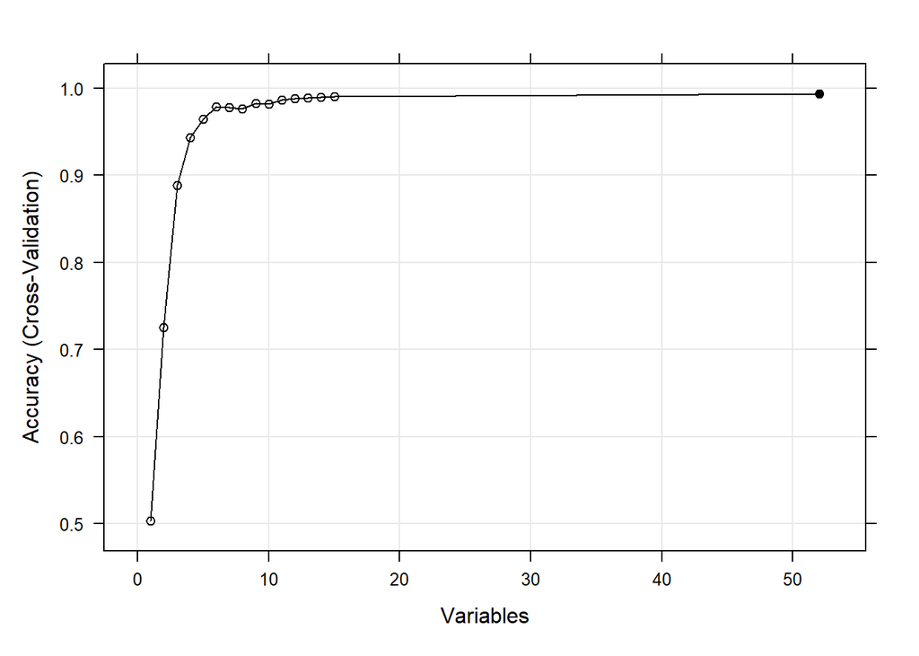

```r
trainData$classe <- as.factor(trainData$classe)
control <- rfeControl(functions = rfFuncs, method = "cv", number = 10)
rfe_model <- rfe(trainData[,1:52], trainData$classe, sizes = c(1:15), rfeControl = control)
trellis.par.set(caretTheme())
plot(rfe_model, type = c("g", "o"))
```

```r
predictors(rfe_model)
```

```
##  [1] "roll_belt"            "yaw_belt"             "magnet_dumbbell_z"
##  [4] "pitch_belt"           "magnet_dumbbell_y"    "pitch_forearm"
##  [7] "accel_dumbbell_y"     "roll_dumbbell"        "roll_forearm"
## [10] "magnet_dumbbell_x"    "magnet_forearm_z"     "roll_arm"
## [13] "accel_dumbbell_z"     "gyros_belt_z"         "magnet_belt_z"
## [16] "magnet_belt_y"        "accel_forearm_x"      "yaw_arm"
## [19] "yaw_dumbbell"         "magnet_belt_x"        "gyros_arm_y"
## [22] "total_accel_dumbbell" "gyros_dumbbell_y"     "accel_forearm_z"
## [25] "accel_belt_z"         "gyros_forearm_y"      "magnet_arm_z"
## [28] "magnet_forearm_y"     "accel_forearm_y"      "gyros_dumbbell_x"
## [31] "accel_dumbbell_x"     "yaw_forearm"          "gyros_arm_x"
## [34] "gyros_forearm_z"      "pitch_arm"            "magnet_forearm_x"
## [37] "gyros_dumbbell_z"     "accel_arm_y"          "total_accel_forearm"
## [40] "total_accel_arm"      "magnet_arm_x"         "accel_arm_z"
## [43] "magnet_arm_y"         "gyros_belt_x"         "accel_arm_x"
## [46] "accel_belt_x"         "gyros_forearm_x"      "pitch_dumbbell"
## [49] "total_accel_belt"     "gyros_belt_y"         "gyros_arm_z"
## [52] "accel_belt_y"
```

The top 6 variables will be used.

## Models

Train and validate each model with the selected variables and the 5-fold cross validation control.

### Decision Tree

```r
rpModel <- train(classe ~ roll_belt + yaw_belt + magnet_dumbbell_z + pitch_belt + magnet_dumbbell_y + pitch_forearm, data = trainData, method = "rpart", trControl = controlCv, tuneLength = 5)
rpPred <- predict(rpModel, validationData)
rpCmatrix <- confusionMatrix(rpPred, as.factor(validationData$classe))
rpCmatrix
```

```
## Confusion Matrix and Statistics
##
##           Reference
## Prediction    A    B    C    D    E
##          A 1266  284  159  182   70
##          B  189  681   77  281  281
##          C  128   72  686  180   89
##          D   87  102  104  321  143
##          E    4    0    0    0  499
##
## Overall Statistics
##
##                Accuracy : 0.5867
##                  95% CI : (0.574, 0.5994)
##     No Information Rate : 0.2845
##     P-Value [Acc > NIR] : < 2.2e-16
##
##                   Kappa : 0.4733
##
##  Mcnemar's Test P-Value : < 2.2e-16
##
## Statistics by Class:
##
##                      Class: A Class: B Class: C Class: D Class: E
## Sensitivity            0.7563   0.5979   0.6686  0.33299  0.46118
## Specificity            0.8350   0.8255   0.9035  0.91140  0.99917
## Pos Pred Value         0.6456   0.4513   0.5939  0.42404  0.99205
## Neg Pred Value         0.8960   0.8953   0.9281  0.87461  0.89168
## Prevalence             0.2845   0.1935   0.1743  0.16381  0.18386
## Detection Rate         0.2151   0.1157   0.1166  0.05455  0.08479
## Detection Prevalence   0.3332   0.2564   0.1963  0.12863  0.08547
## Balanced Accuracy      0.7956   0.7117   0.7860  0.62219  0.73018
```

### Gradient Boosting

```r
gbmModel <- train(classe ~ roll_belt + yaw_belt + magnet_dumbbell_z + pitch_belt + magnet_dumbbell_y + pitch_forearm, data = trainData, method = "gbm", trControl = controlCv, tuneLength = 5, verbose = FALSE)
gbmPred <- predict(gbmModel, validationData)
gbmCmatrix <- confusionMatrix(gbmPred, as.factor(validationData$classe))
gbmCmatrix
```

```
## Confusion Matrix and Statistics
##
##           Reference
## Prediction    A    B    C    D    E
##          A 1628   25    4    1    3
##          B   19 1068   26    4   11
##          C   20   27  979   35    6
##          D    5   14   17  911    8
##          E    2    5    0   13 1054
##
## Overall Statistics
##
##                Accuracy : 0.9584
##                  95% CI : (0.9529, 0.9633)
##     No Information Rate : 0.2845
##     P-Value [Acc > NIR] : < 2.2e-16
##
##                   Kappa : 0.9474
##
##  Mcnemar's Test P-Value : 9.87e-05
##
## Statistics by Class:
##
##                      Class: A Class: B Class: C Class: D Class: E
## Sensitivity            0.9725   0.9377   0.9542   0.9450   0.9741
## Specificity            0.9922   0.9874   0.9819   0.9911   0.9958
## Pos Pred Value         0.9801   0.9468   0.9175   0.9539   0.9814
## Neg Pred Value         0.9891   0.9851   0.9902   0.9892   0.9942
## Prevalence             0.2845   0.1935   0.1743   0.1638   0.1839
## Detection Rate         0.2766   0.1815   0.1664   0.1548   0.1791
## Detection Prevalence   0.2822   0.1917   0.1813   0.1623   0.1825
## Balanced Accuracy      0.9823   0.9625   0.9680   0.9680   0.9850
```

### Support Vector Machine

```r
svmModel <- train(classe ~ roll_belt + yaw_belt + magnet_dumbbell_z + pitch_belt + magnet_dumbbell_y + pitch_forearm, data = trainData, method = "svmLinear", trControl = controlCv, tuneLength = 5, verbose = FALSE)
svmPred <- predict(svmModel, validationData)
svmCmatrix <- confusionMatrix(svmPred, as.factor(validationData$classe))
svmCmatrix
```

```
## Confusion Matrix and Statistics
##
##           Reference
## Prediction    A    B    C    D    E
##          A 1057  337  284  136  266
##          B  167   89   21   10  166
##          C  105  206  323  128  138
##          D  189  213  134  498  203
##          E  156  294  264  192  309
##
## Overall Statistics
##
##                Accuracy : 0.3867
##                  95% CI : (0.3743, 0.3993)
##     No Information Rate : 0.2845
##     P-Value [Acc > NIR] : < 2.2e-16
##
##                   Kappa : 0.2193
##
##  Mcnemar's Test P-Value : < 2.2e-16
##
## Statistics by Class:
##
##                      Class: A Class: B Class: C Class: D Class: E
## Sensitivity            0.6314  0.07814  0.31481  0.51660  0.28558
## Specificity            0.7571  0.92330  0.88125  0.84983  0.81137
## Pos Pred Value         0.5082  0.19647  0.35889  0.40259  0.25432
## Neg Pred Value         0.8378  0.80670  0.85898  0.89974  0.83448
## Prevalence             0.2845  0.19354  0.17434  0.16381  0.18386
## Detection Rate         0.1796  0.01512  0.05489  0.08462  0.05251
## Detection Prevalence   0.3534  0.07698  0.15293  0.21020  0.20646
## Balanced Accuracy      0.6942  0.50072  0.59803  0.68321  0.54848
```

### Random Forest

```r
rfModel <- train(classe ~ roll_belt + yaw_belt + magnet_dumbbell_z + pitch_belt + magnet_dumbbell_y + pitch_forearm, data = trainData, method = "rf", trControl = controlCv)
rfPred <- predict(rfModel, validationData)
rfCmatrix <- confusionMatrix(rfPred, as.factor(validationData$classe))
rfCmatrix
```

```
## Confusion Matrix and Statistics
##
##           Reference
## Prediction    A    B    C    D    E
##          A 1650    8    0    2    2
##          B    8 1111    7    1    4
##          C   11   15 1017   17    3
##          D    4    4    2  937    2
##          E    1    1    0    7 1071
##
## Overall Statistics
##
##                Accuracy : 0.9832
##                  95% CI : (0.9796, 0.9863)
##     No Information Rate : 0.2845
##     P-Value [Acc > NIR] : < 2.2e-16
##
##                   Kappa : 0.9787
##
##  Mcnemar's Test P-Value : 7.999e-05
##
## Statistics by Class:
##
##                      Class: A Class: B Class: C Class: D Class: E
## Sensitivity            0.9857   0.9754   0.9912   0.9720   0.9898
## Specificity            0.9972   0.9958   0.9905   0.9976   0.9981
## Pos Pred Value         0.9928   0.9823   0.9567   0.9874   0.9917
## Neg Pred Value         0.9943   0.9941   0.9981   0.9945   0.9977
## Prevalence             0.2845   0.1935   0.1743   0.1638   0.1839
## Detection Rate         0.2804   0.1888   0.1728   0.1592   0.1820
## Detection Prevalence   0.2824   0.1922   0.1806   0.1613   0.1835
## Balanced Accuracy      0.9914   0.9856   0.9909   0.9848   0.9940
```

### Model comparisson

```r
results <- data.frame(Accuracy = c(rpCmatrix$overall[1], gbmCmatrix$overall[1], svmCmatrix$overall[1], rfCmatrix$overall[1]), Kappa = c(rpCmatrix$overall[2], gbmCmatrix$overall[2], svmCmatrix$overall[2], rfCmatrix$overall[2]))
row.names(results) <- c("Decision Tree", "Gradient Boosting", "Support Vector Machine", "Random Forest")
results
```

```
##                         Accuracy     Kappa
## Decision Tree          0.5867460 0.4732838
## Gradient Boosting      0.9583687 0.9473604
## Support Vector Machine 0.3867460 0.2192946
## Random Forest          0.9831776 0.9787280
```

When dealing with multiclass classification, concordance is a common error measure. Caret already calculates the kappa value, and in this case the random forest is the model with both the highest accuracy (0.9831776) and kappa (0.978728).

## Prediction

Prediction usin the random forest model.

```r
rfTestPred <- predict(rfModel, rawTestData)
print(rfTestPred)
```

```
##  [1] B A B A A E D B A A B C B A E E A B B B
## Levels: A B C D E
```

## Appendix

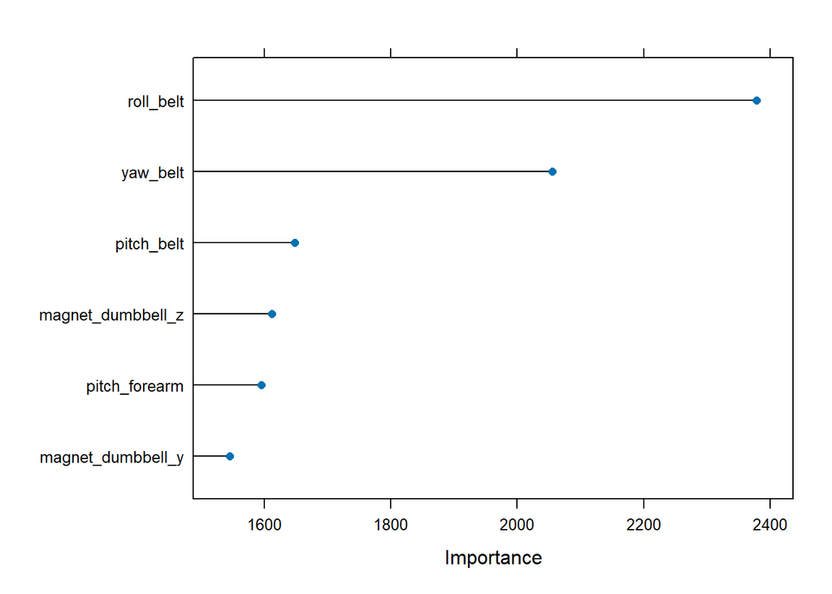

```r
importance <- varImp(rfModel, scale = FALSE)
plot(importance)
```

This plot indicates that most of the information comes from the belt sensors.

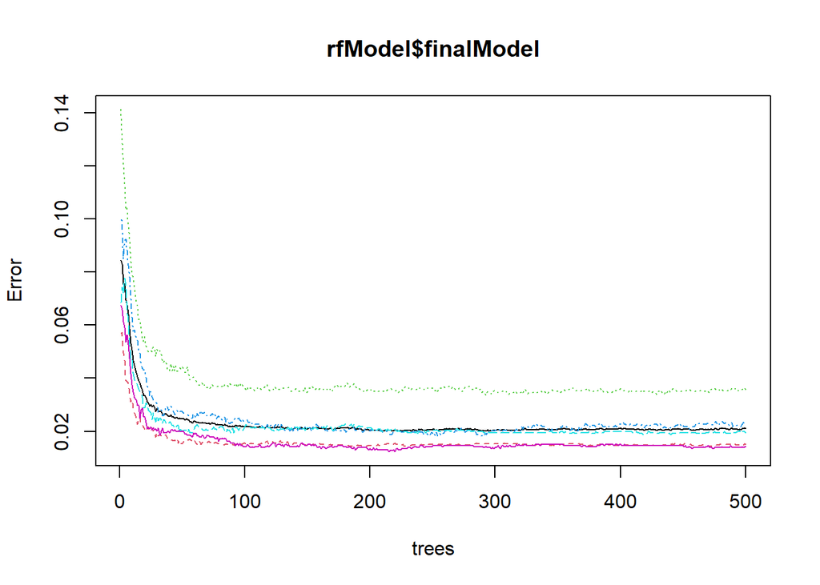

```r
plot(rfModel$finalModel)
```

This plot show that generating around 100 trees would have been enough to achieve a similar performance, instead the 500 used.